# Human Activity Recognition - machine learning algorithm

## Building the model

At first, It was planning to use the random forest method [2] and analyze the OOB estimate error rate. If it was not satisfactory (less than 1%), different methods could be tried.

```r
# Building the Model
library(randomForest)
model1 = randomForest(classe ~., data=dataTrainingPml)
model1
```

```
##
## Call:
##  randomForest(formula = classe ~ ., data = dataTrainingPml)
##                Type of random forest: classification
##                      Number of trees: 500
## No. of variables tried at each split: 7
##
##         OOB estimate of  error rate: 0.52%
## Confusion matrix:
##      A    B    C    D    E class.error
## A 3903    2    0    1    0    0.000768
## B   10 2639    9    0    0    0.007148
## C    0   12 2379    5    0    0.007095
## D    0    0   21 2229    2    0.010213
## E    0    0    1    9 2515    0.003960
```

The **OOB estimate of error rate** obtained was 0.52%, less than 1% (satisfactory).

Now, it plotted the model in order to show the overall error of the model by trees.

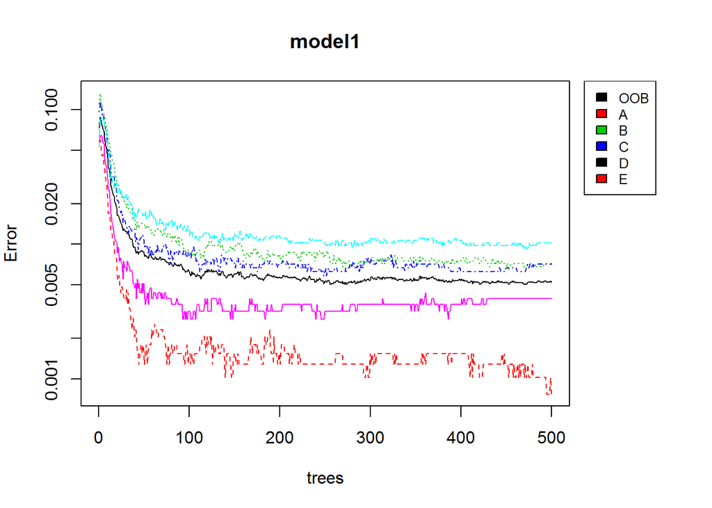

```r
layout(matrix(c(1,2),nrow=1),
       width=c(4,1))
par(mar=c(5,4,4,0))
plot(model1, log="y")
par(mar=c(5,0,4,2))
plot(c(0,1),type="n", axes=F, xlab="", ylab="")
legend("top", colnames(model1$err.rate),col=1:4,cex=0.8,fill=1:4)
```

## Cross-validation

In this step, it performs the cross-validation test to classify the test set (30%) of the training set. A confusion matrix is used in order to analyze the model’s accuracy.

```r
# crossvalidating
validPredict <- predict(model1, validTestingPml)
confusionMatrix(validTestingPml$classe, validPredict)
```

```
## Confusion Matrix and Statistics
##
##           Reference
## Prediction    A    B    C    D    E
##          A 1674    0    0    0    0
##          B    5 1131    3    0    0
##          C    0    2 1024    0    0
##          D    0    0    8  955    1
##          E    0    0    5    7 1070
##
## Overall Statistics
##
##                Accuracy : 0.995
##                  95% CI : (0.993, 0.996)
##     No Information Rate : 0.285
##     P-Value [Acc > NIR] : <2e-16
##
##                   Kappa : 0.993
##  Mcnemar's Test P-Value : NA
##
## Statistics by Class:
##
##                      Class: A Class: B Class: C Class: D Class: E
## Sensitivity             0.997    0.998    0.985    0.993    0.999
## Specificity             1.000    0.998    1.000    0.998    0.998
## Pos Pred Value          1.000    0.993    0.998    0.991    0.989
## Neg Pred Value          0.999    1.000    0.997    0.999    1.000
## Prevalence              0.285    0.193    0.177    0.163    0.182
## Detection Rate          0.284    0.192    0.174    0.162    0.182
## Detection Prevalence    0.284    0.194    0.174    0.164    0.184
## Balanced Accuracy       0.999    0.998    0.992    0.995    0.998
```

The accuracy obtained was 99.5%, that means the model has a very good prediction for different data set.

## Using the prediction model to predict

Now, the original test data is used to predict 20 different test cases, according to project requisites:

```r
# predict
predictTest <- predict(model1, newPmlTesting)
predictTest
```

```
##  1  2  3  4  5  6  7  8  9 10 11 12 13 14 15 16 17 18 19 20
##  B  A  B  A  A  E  D  B  A  A  B  C  B  A  E  E  A  B  B  B
## Levels: A B C D E
```

## Conclusion

The model obtained shows that random forest method was very satisfactory for the presented problem. As a result, further exploration of alternative models was not necessary.

## References

1. Velloso, E.; Bulling, A.; Gellersen, H.; Ugulino, W.; Fuks, H. Qualitative Activity Recognition of Weight Lifting Exercises. Proceedings of 4th International Conference in Cooperation with SIGCHI (Augmented Human ’13) . Stuttgart, Germany: ACM SIGCHI, 2013. [ONLINE] Available at http://groupware.les.inf.puc-rio.br/public/papers/2013.Velloso.QAR-WLE.pdf and http://groupware.les.inf.puc-rio.br/har#ixzz3RxdqVyEe [Accessed 17 February 2015].
2. Breiman, L. (2001). Random forests. Machine Learning, 45(1), 5-32.